# Efectos del consumo de transgénicos en la salud

Fuentes de datos Biomédicas y Web semántica Grado de Ingeniería de la Salud

Samuel Espiño, Lucía Gil, Alvar Tomás Ortiz

2023-12-11

## 1. Introducción

En este estudio, se pretende conocer que relación existe entre los cultivos transgénicos con los siguientes temas, utilizado solo valores de entre 2015-2020 : cancer de mama, isquemia cardiaca y abortos.

## 2. Objetivo específicos:

Se plantea relacionar los siguientes puntos con tres cultivos que hemos seleccionado para relacionar:

1. **Aborto:** No existe ningún tipo de evidencia cientifica que relacione el consumo de coliflor, pepino o judía verde con la tasa de aborto, por ello hemos escogido este factor como muestra control, para comparar su nulo efecto con el impacto en otras patologías.
2. **Cancer de Mama:** El desarrollo de cáncer de mama viene dado por múltiples factores, algunos de ellos correspondientes con componentes genéticos y otros relacionados con la dieta. Está demostrado que una dieta rica en frutas y verduras ayuda la prevención del cáncer de mama. En relación a esta dieta, queremos comprobar si el cultivo de productos transgénicos diseñados para que tengan unas propiedades más saludables dietéticamente influyen o no en el desarrollo de esta enfermedad y si lo hacen de forma positiva.
3. **Isquemia cardiaca:** La coliflor, el pepino y la judía verde son alimentos ricos en fibra, vitaminas, minerales y antioxidantes que contribuyen a la reducción del colesterol, la presión arterial, la inflamación y el estrés oxidativo, que son factores de riesgo que producen la isquemia cardiaca, por lo que queremos investigar si existe una relación en los paises en los que se cultivan estos cultivos con la isquemia cardiaca.

## 3. Tratamiento de datos

### 3.1. Librerias que importamos para el trabajo

```r
library(tidyverse)
library(readxl)
```

### 3.2. Importamos las tablas

Los archivos importados en este proyecto se encuentran descargados en la carpeta “DATA” en la que los datos de casos de abortos y cancer de mama son archivos .tsv y los casos de isquemia y los datos de los cultivos se encuentran en archivos .xlsx .

- Tabla de cultivos a nivel global

```r
d_cultivos <- read_excel("INPUT/DATA/datos_cultivos.xlsx") %>%
  rename(Pais = "Country ISO2 code" )
d_cultivos
```

```
## # A tibble: 206 × 175
##    Pais  `Country Name` abaca agave    alfalfa   almond aniseetc   apple apricot
##    <chr> <chr>          <dbl> <dbl>      <dbl>    <dbl>    <dbl>   <dbl>   <dbl>
##  1 AF    Afghanistan        0     0      50.8     35.2   2.47e+0 1.88e+2 4.64e+1
##  2 AL    Albania            0     0   72010.      23.5   2.65e-1 2.03e+3 3.57e+2
##  3 DZ    Algeria            0     0    3940.   26798.    3.57e+1 1.92e+4 2.12e+4
##  4 AD    Andorra            0     0       1.74     2.28  5.67e-3 3.40e-1 1.22e-1
##  5 AO    Angola             0     0       0        0     0       0       0
##  6 AG    Antigua            0     0       0        0     0       0       0
##  7 AR    Argentina          0     0 1537869.     235.    3.31e+3 4.44e+4 2.50e+3
##  8 AM    Armenia            0     0      62.3     81.1   5.34e+0 6.21e+3 3.17e+3
##  9 AU    Australia          0     0  187586.    8240.    0       2.37e+4 3.19e+3
## 10 AT    Austria            0     0    6777.       5.97  4.39e-1 1.19e+4 2.07e+3
## # ℹ 196 more rows
## # ℹ 166 more variables: areca <dbl>, artichoke <dbl>, asparagus <dbl>,
## #   avocado <dbl>, bambara <dbl>, banana <dbl>, barley <dbl>, bean <dbl>,
## #   beetfor <dbl>, berrynes <dbl>, blueberry <dbl>, brazil <dbl>,
## #   broadbean <dbl>, buckwheat <dbl>, cabbage <dbl>, cabbagefor <dbl>,
## #   canaryseed <dbl>, carob <dbl>, carrot <dbl>, carrotfor <dbl>, cashew <dbl>,
## #   cashewapple <dbl>, cassava <dbl>, castor <dbl>, cauliflower <dbl>, …
```

Renombramos la tabla “Country ISO2 code” a “Pais” para facilitar la selección

- Tabla de abortos a nivel europeo

```r
aborto <- read_delim("INPUT/DATA/datos_aborto.tsv",
    delim = "\t", escape_double = FALSE,
    trim_ws = TRUE) %>%
    separate(col = 1, into = c("A","ABORT","RT","Pais"), sep = ",") %>%
    mutate(across("2013":"2021", ~na_if(.,":"))) %>%
    mutate(across("2013":"2021", ~as.numeric(.))) %>%
    select(.,Pais:"2021") %>%
    pivot_longer(
    cols = "2013":"2021",
    names_to = "Años",
    values_to = "Valores"
  )
aborto
```

```
## # A tibble: 261 × 3
##    Pais  Años  Valores
##    <chr> <chr>   <dbl>
##  1 AL    2013     NA
##  2 AL    2014      6.1
##  3 AL    2015      6.2
##  4 AL    2016     NA
##  5 AL    2017      1.1
##  6 AL    2018      1.3
##  7 AL    2019      1
##  8 AL    2020      1.2
##  9 AL    2021     NA
## 10 AM    2013     NA
## # ℹ 251 more rows
```

- Tabla de cancer de Mama a nivel europeo

```r
d_mama <- read_delim("INPUT/DATA/datos_cancer_mama.tsv",
    delim = "\t", escape_double = FALSE,
    trim_ws = TRUE) %>%
  separate(col = 1, into = c("A","PC","PGR","C50","Pais"), sep = ",") %>%
  mutate(across("2000":"2021", ~na_if(.,":"))) %>%
  select(.,Pais:"2021") %>%
  pivot_longer(cols="2000":"2021",
               names_to = "Años",
               values_to = "Valores") %>%
  mutate(Valores = as.numeric(gsub("[^0-9.]", "", Valores)))
d_mama
```

```
## # A tibble: 638 × 3
##    Pais  Años  Valores
##    <chr> <chr>   <dbl>
##  1 BE    2000     NA
##  2 BE    2001     50
##  3 BE    2002     54
##  4 BE    2003     53.7
##  5 BE    2004     55.9
##  6 BE    2005     56.6
##  7 BE    2006     60.1
##  8 BE    2007     62
##  9 BE    2008     62.2
## 10 BE    2009     62.5
## # ℹ 628 more rows
```

Tratamos los datos para obtener tres columnas, una con el país del que hablamos, otra del año de la medición y otra con el valor correspondiente de casos de cáncer de mama (en porcentaje).

- Tabla de Isquemias cardiacas a nivel mundial

```r
d_isquemia <- read_excel("INPUT/DATA/datos_isquemias.xlsx",
    sheet = "Data (pivoted)") %>%
  select(.,COUNTRY_REGION:"2020") %>%
  pivot_longer(cols = -c("COUNTRY_REGION"),
               names_to = "Años",
               values_to = "Valor") %>%
  rename(.,Pais=COUNTRY_REGION)
d_isquemia
```

```
## # A tibble: 8,427 × 3
##    Pais  Años  Valor
##    <chr> <chr> <dbl>
##  1 ALB   1968     NA
##  2 ALB   1969     NA
##  3 ALB   1970     NA
##  4 ALB   1971     NA
##  5 ALB   1972     NA
##  6 ALB   1973     NA
##  7 ALB   1974     NA
##  8 ALB   1975     NA
##  9 ALB   1976     NA
## 10 ALB   1977     NA
## # ℹ 8,417 more rows
```

Tratamos la tabla para que salga en tres columnas, siendo el pais, el año y el valor de ese año de isquemia, esto lo hacemos para que resulte mas facil la selección de datos.

### 3.3. Seleccionamos los datos

- Selección de los 3 cultivos que vamos a usar para buscar la relación

```r
d_cultivos_e <- select(d_cultivos,Pais,cauliflower,cucumberetc,greenbean) %>%
  rename(Pepino="cucumberetc",Judía_verde="greenbean",Coliflor="cauliflower") %>%
  pivot_longer(cols = -Pais, names_to = "Cultivo", values_to = "Hectareas_cultivadas")

d_cultivos_e
```

```
## # A tibble: 618 × 3
##    Pais  Cultivo     Hectareas_cultivadas
##    <chr> <chr>                      <dbl>
##  1 AF    Coliflor                   2.44
##  2 AF    Pepino                    21.3
##  3 AF    Judía_verde                1.14
##  4 AL    Coliflor                   2.52
##  5 AL    Pepino                     3.12
##  6 AL    Judía_verde              403.
##  7 DZ    Coliflor                3760.
##  8 DZ    Pepino                  2895.
##  9 DZ    Judía_verde             6046.
## 10 AD    Coliflor                   0.162
## # ℹ 608 more rows
```

Seleccionamos los tres cultivos con los que vamos a trabajar y modificamos la tabla a tres columnas(Pais,Cultivo y hectarias_cultivadas) para que la selección de datos sea mas facil.

- Seleccion de la media de los años 2015-2020 en casos de abortos a nivel europeo

```r
aborto_media <- aborto %>%
  filter(Años >= 2015 & Años <= 2020) %>%
  group_by(Pais) %>%
  summarise(Valor_Media = mean(Valores, na.rm = TRUE))
aborto_media
```

```
## # A tibble: 29 × 2
##    Pais   Valor_Media
##    <chr>        <dbl>
##  1 AL            2.16
##  2 AM           11.4
##  3 AZ           10.6
##  4 BG           12.7
##  5 BY            9.28
##  6 CH            4.2
##  7 CZ            6.47
##  8 DE            4.63
##  9 DE_TOT        4.63
## 10 DK          NaN
## # ℹ 19 more rows
```

- Selección de la media de los años 2015-2020 en casos de cancer de mama a nivel europeo

```r
casos_mama_media <- d_mama %>%
  filter(Años >= 2015 & Años <= 2020) %>%
  group_by(Pais) %>%
  summarise(Valor_Media = mean(Valores, na.rm = TRUE))
casos_mama_media
```

```
## # A tibble: 29 × 2
##    Pais  Valor_Media
##    <chr>       <dbl>
##  1 BE           60.9
##  2 BG           18.5
##  3 CY           34.0
##  4 CZ           60.2
##  5 DE           50.4
##  6 DK           83
##  7 EE           54.2
##  8 FI           81.8
##  9 FR           48.9
## 10 HR           60
## # ℹ 19 more rows
```

Seleccionamos las medias de los años para obtener para cada país un único valor de cáncer de mama.

- Selección de la media de los años 2015-2020 en casos de cardiopatias isquémicas a nivel europeo

```r
paises <- read_excel("INPUT/DATA/datos_isquemias.xlsx",
    sheet = "Countries") %>%
  select(.,"ISO 2","ISO 3") %>%
  inner_join(.,select(casos_mama_media,Pais), by = c("ISO 2" = "Pais"))

d_isquemia_media <- d_isquemia %>%
  filter(Años >= 2015 & Años <= 2020) %>%
  group_by(Pais) %>%
  summarise(Valor_Media = mean(Valor, na.rm = TRUE)) %>%
  rename (., Media_isquemia = Valor_Media) %>%
  inner_join(.,paises, by = c("Pais" = "ISO 3")) %>%
  relocate("ISO 2", .before =Media_isquemia) %>%
  select(.,"ISO 2", Media_isquemia) %>%
  rename(., Pais = "ISO 2") %>%
  mutate(., Media_isquemia = (Media_isquemia/sum(Media_isquemia)*100))
d_isquemia_media
```

```
## # A tibble: 27 × 2
##    Pais  Media_isquemia
##    <chr>          <dbl>
##  1 BE             1.46
##  2 BG             2.59
##  3 CY             0.128
##  4 CZ             4.73
##  5 DE            24.4
##  6 DK             0.695
##  7 EE             0.620
##  8 FI             1.85
##  9 FR             6.41
## 10 HR             1.92
## # ℹ 17 more rows
```

Seleccionamos solo los datos de los paises europeos y la media entre los años 2015-2020 y renombramos las columnas de interés, también calculamos los valores de cada pais por porcentaje.

### 3.4. Relación de los datos con los cultivos

Creamos las tablas cohesionadas con la relación cultivos-enfermedad para que nos permita un mejor manejo de la información y renombramos las columnas para trabajar con los datos mejor

- Aborto

```r
tabla_aborto <- left_join(aborto_media, d_cultivos_e, by = 'Pais') %>%
  rename(Media_abortos=Valor_Media) %>%
  relocate(Cultivo:Hectareas_cultivadas, .before =Media_abortos)
tabla_aborto
```

```
## # A tibble: 83 × 4
##    Pais  Cultivo     Hectareas_cultivadas Media_abortos
##    <chr> <chr>                      <dbl>         <dbl>
##  1 AL    Coliflor                    2.52          2.16
##  2 AL    Pepino                      3.12          2.16
##  3 AL    Judía_verde               403.            2.16
##  4 AM    Coliflor                  174.           11.4
##  5 AM    Pepino                   2445.           11.4
##  6 AM    Judía_verde                 7.32         11.4
##  7 AZ    Coliflor                   15.1          10.6
##  8 AZ    Pepino                   7735.           10.6
##  9 AZ    Judía_verde                 1.11         10.6
## 10 BG    Coliflor                  258.           12.7
## # ℹ 73 more rows
```

- Cancer mama

```r
unif_mama_cult <- casos_mama_media %>%
  inner_join(., d_cultivos_e) %>%
  rename (.data = ., Media_Cancer = Valor_Media) %>%
  relocate (.data = ., Cultivo:Hectareas_cultivadas, .before = Media_Cancer)
unif_mama_cult
```

```
## # A tibble: 81 × 4
##    Pais  Cultivo     Hectareas_cultivadas Media_Cancer
##    <chr> <chr>                      <dbl>        <dbl>
##  1 BE    Coliflor                  2725.          60.9
##  2 BE    Pepino                      75.1         60.9
##  3 BE    Judía_verde               2830.          60.9
##  4 BG    Coliflor                   258.          18.5
##  5 BG    Pepino                    7831.          18.5
##  6 BG    Judía_verde               4419.          18.5
##  7 CY    Coliflor                     0           34.0
##  8 CY    Pepino                       0           34.0
##  9 CY    Judía_verde                  0           34.0
## 10 CZ    Coliflor                  1596.          60.2
## # ℹ 71 more rows
```

- Isquemias cardiacas

```r
tabla_isquemia <- d_isquemia_media %>%
  inner_join(.,d_cultivos_e) %>%
  relocate(Cultivo:Hectareas_cultivadas, .before =Media_isquemia)
tabla_isquemia
```

```
## # A tibble: 81 × 4
##    Pais  Cultivo     Hectareas_cultivadas Media_isquemia
##    <chr> <chr>                      <dbl>          <dbl>
##  1 BE    Coliflor                  2725.           1.46
##  2 BE    Pepino                      75.1          1.46
##  3 BE    Judía_verde               2830.           1.46
##  4 BG    Coliflor                   258.           2.59
##  5 BG    Pepino                    7831.           2.59
##  6 BG    Judía_verde               4419.           2.59
##  7 CY    Coliflor                     0            0.128
##  8 CY    Pepino                       0            0.128
##  9 CY    Judía_verde                  0            0.128
## 10 CZ    Coliflor                  1596.           4.73
## # ℹ 71 more rows
```

### 3.5. Desarrollo de gráficas de las relaciones

Crearemos las graficas con las relaciones cultivos-enfermedad para evaluar el impacto de los cultivos de cada pais con la tasa a nivel europeo para estudiar las posibles relaciones.

- Aborto-Coliflor

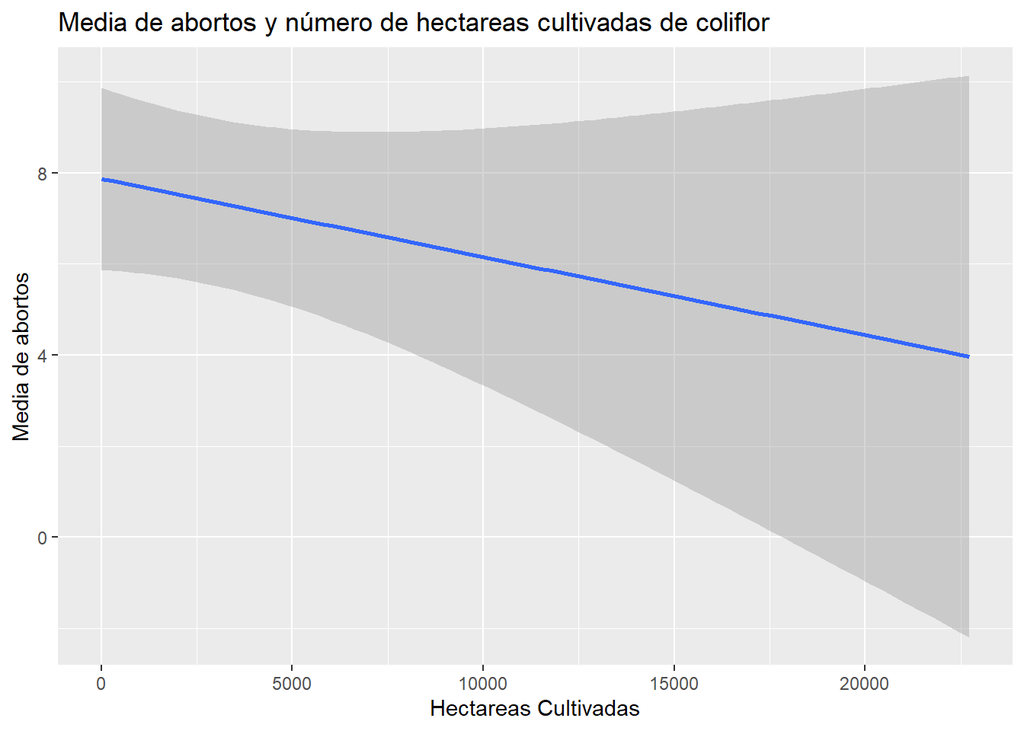

```r
fig_a_coliflor <-ggplot(data = filter(tabla_aborto,Cultivo=="Coliflor")) +
  geom_smooth(
    mapping = aes (x = Hectareas_cultivadas, y = Media_abortos),
    method = "lm"
  ) +
  labs(
    x = "Hectareas Cultivadas",
    y = "Media de abortos",
    title = "Media de abortos y número de hectareas cultivadas de coliflor",
  )
fig_a_coliflor
```

- Aborto-Pepino

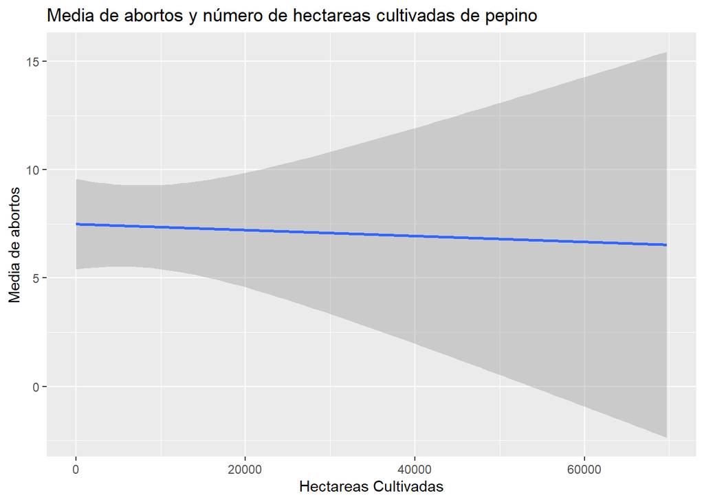

```r
fig_a_pepino <- ggplot(data = filter(tabla_aborto,Cultivo=="Pepino")) +
  geom_smooth(
    mapping = aes (x = Hectareas_cultivadas, y = Media_abortos),
    method = "lm"
  ) +
  labs(
    x = "Hectareas Cultivadas",
    y = "Media de abortos",
    title = "Media de abortos y número de hectareas cultivadas de pepino",
  )
fig_a_pepino
```

- Aborto-Judía

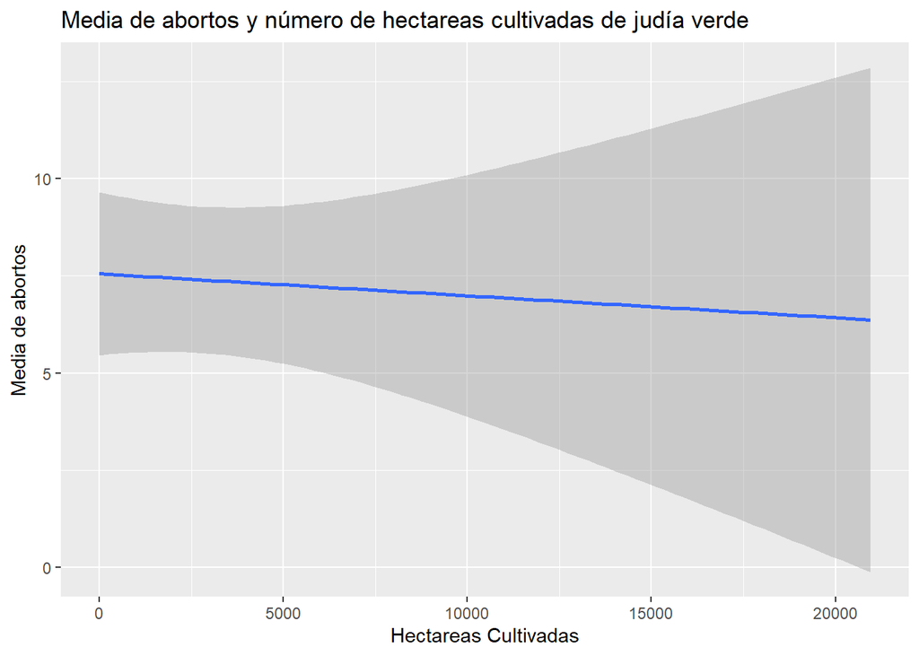

```r
fig_a_judia <- ggplot(data = filter(tabla_aborto,Cultivo=="Judía_verde")) +
  geom_smooth(
    mapping = aes (x = Hectareas_cultivadas, y = Media_abortos),
    method = "lm"
  ) +
  labs(
    x = "Hectareas Cultivadas",
    y = "Media de abortos",
    title = "Media de abortos y número de hectareas cultivadas de judía verde",
  )
fig_a_judia
```

- Cancer-Coliflor

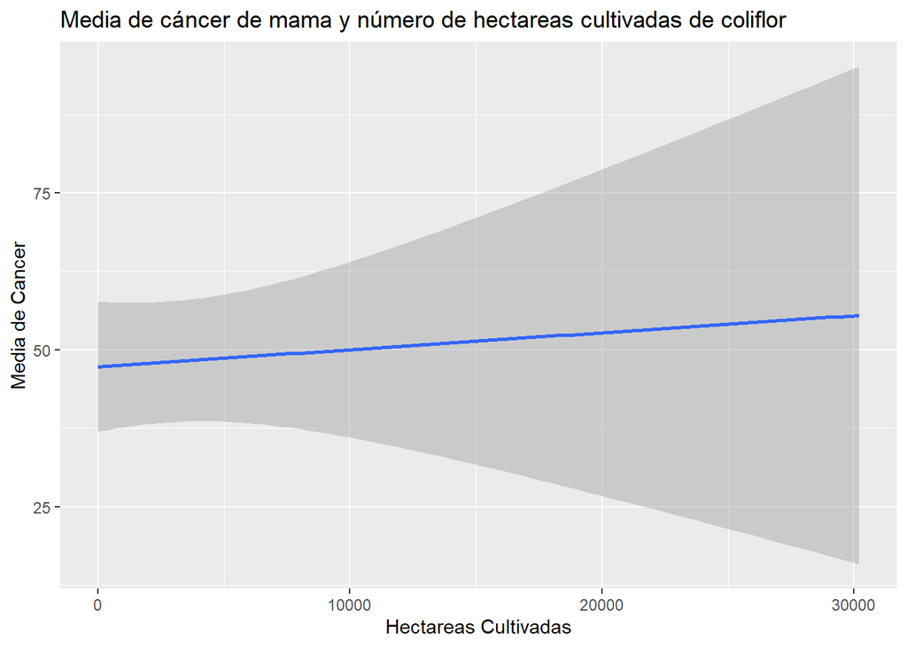

```r
fig_c_coliflor <- ggplot(data = filter(unif_mama_cult,Cultivo=="Coliflor")) +
  geom_smooth(
    mapping = aes (x = Hectareas_cultivadas, y = Media_Cancer),
    method = "lm"
  ) +
  labs(
    x = "Hectareas Cultivadas",
    y = "Media de Cancer",
    title = "Media de cáncer de mama y número de hectareas cultivadas de coliflor",
  )
fig_c_coliflor
```

- Cancer-Pepino

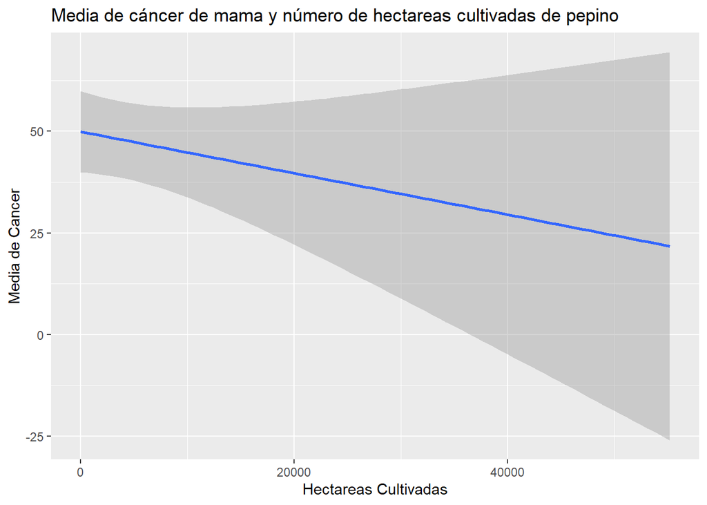

```r
fig_c_pepino <- ggplot(data = filter(unif_mama_cult,Cultivo=="Pepino")) +
  geom_smooth(
    mapping = aes (x = Hectareas_cultivadas, y = Media_Cancer),
    method = "lm",
  ) +
  labs(
    x = "Hectareas Cultivadas",
    y = "Media de Cancer",
    title = "Media de cáncer de mama y número de hectareas cultivadas de pepino",
  )
fig_c_pepino
```

- Cancer-Judía

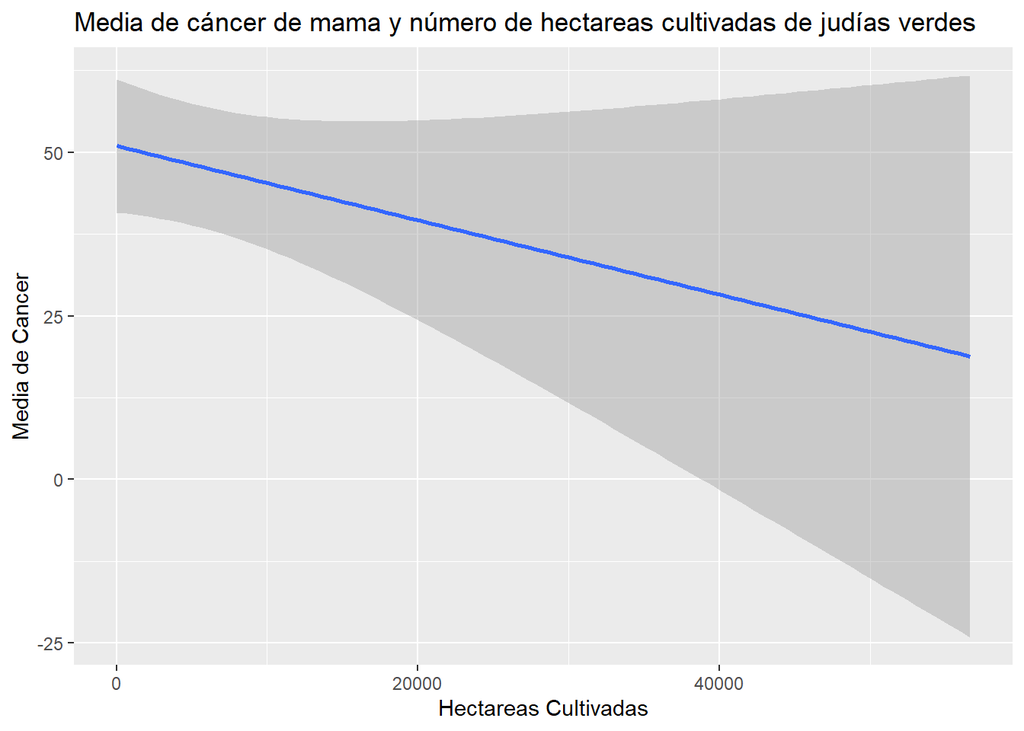

```r
fig_c_judia <-ggplot(data = filter(unif_mama_cult,Cultivo=="Judía_verde")) +
  geom_smooth(
    mapping = aes (x = Hectareas_cultivadas, y = Media_Cancer),
    method = "lm"
  ) +
  labs(
    x = "Hectareas Cultivadas",
    y = "Media de Cancer",
    title = "Media de cáncer de mama y número de hectareas cultivadas de judías verdes",
  )
fig_c_judia
```

- Isquemia-Coliflor

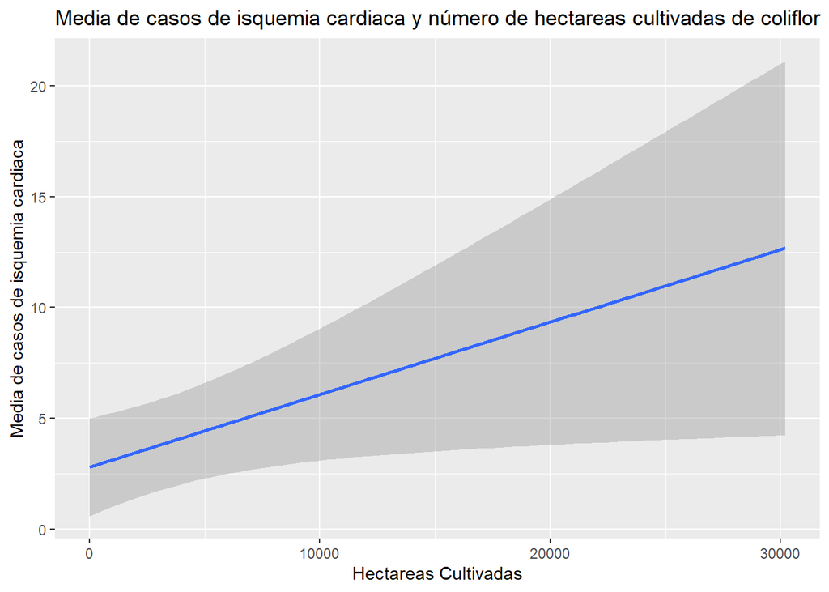

```r
fig_i_coliflor <- ggplot(data = filter(tabla_isquemia,Cultivo=="Coliflor")) +
  geom_smooth(
    mapping = aes (x = Hectareas_cultivadas, y = Media_isquemia),
    method = "lm"
  ) +
  labs(
    x = "Hectareas Cultivadas",
    y = "Media de casos de isquemia cardiaca",
    title = "Media de casos de isquemia cardiaca y número de hectareas cultivadas de coliflor",
  )
fig_i_coliflor
```

- Isquemia-Pepino

[figure not shown]

```r
fig_i_pepino <- ggplot(filter(tabla_isquemia,Cultivo=="Pepino")) +
  geom_smooth(
    mapping = aes (x = Hectareas_cultivadas, y = Media_isquemia),
    method = "lm"
  ) +
  labs(
    x = "Hectareas Cultivadas",
    y = "Media de casos de isquemia cardiaca",
    title = "Media de casos de isquemia cardiaca y número de hectareas cultivadas de coliflor",
  )
fig_i_pepino
```

- Isquemia-Judía

[figure not shown]

```r
fig_i_judia <- ggplot(data = filter(tabla_isquemia,Cultivo=="Judía_verde")) +
  geom_smooth(
    mapping = aes (x = Hectareas_cultivadas, y = Media_isquemia),
    method = "lm"
  ) +
  labs(
    x = "Hectareas Cultivadas",
    y = "Media de casos de isquemia",
    title = "Media de casos de isquemia y número de hectareas cultivadas de coliflor",
  )
fig_i_judia
```

## 5. Bibliografía

- Conjunto de datos globales georreferenciado de 173 cultivos alrededor de 2020: [Here](https://figshare.com/articles/dataset/CROPGRIDS/22491997?file=41952177)
- Insuficiencia cardiaca: [Here](https://ec.europa.eu/eurostat/databrowser/view/hlth_ehis_pa2u/default/table?lang=en)
- Indice de abortos en Europa: [Here](https://ec.europa.eu/eurostat/databrowser/view/demo_fabortind/default/table?lang=en)
- Cancer de mama : [Here](https://ec.europa.eu/eurostat/databrowser/view/hlth_ps_scre__custom_8587007/default/table?lang=en)
- Cardiopatias isquémicas: [Here](https://gateway.euro.who.int/en/indicators/hfamdb_427-deaths-ischaemic-heart-disease/#id=30289)